# Psychometric modeling of the Syntactic Complexity Scale of the CDI

Seamus Donnelly

```r
library(wordbankr) # WB data
library(tidyverse) # tidy
library(mirt) # IRT models
library(ltm) # more IRT functions
library(psych) # some psychometric stuff (tests of dimensionality)
library(Gifi)# some more psychometric stuff (tests of dimensionality)
library(knitr) # some formatting, tables, etc
library(patchwork) # combining plots.
library(GGally) # More plottinng options.
library(lordif) # differential item functioning.
library(sirt) # additional IRT functions
library(vegan)
```

```r
Inst <- get_instrument_data(language="English (American)", form="WS")
Admin <- get_administration_data(language="English (American)", form="WS")
N_total = nrow(Admin) # making sure things add up later
N_long = nrow(filter(Admin, longitudinal==TRUE)) # making sure things add up later
Item <- get_item_data(language="English (American)", form = "WS")
```

```r
Complex <- Admin %>%
  full_join(.,Inst, by="data_id") %>%
  full_join(., Item, by="num_item_id") %>%
  filter(longitudinal==FALSE) %>%
  filter(type == "combine" |
           type == "complexity" |
           type == "word_endings" |
           type== "word_forms_nouns" |
           type == "word_forms_verbs" |
           type == "word_endings_nouns" |
           type == "word_endings_verbs"
         ) %>%
  mutate(
    out = ifelse(value=="complex" | value=="sometimes" | value=="produces", yes=1,
                 no = ifelse(value=="often", yes=2, no =0))
  )
N_complexity_items = nrow(filter(Item, type == "combine" |
           type == "complexity" |
           type == "word_endings" |
           type== "word_forms_nouns" |
           type == "word_forms_verbs" |
           type == "word_endings_nouns" |
           type == "word_endings_verbs"))

nrow(Complex) == (N_total - N_long)*N_complexity_items
```

```
## [1] TRUE
```

As a quick sanity check, let’s see which items have ordinal data (to make sure the above code worked correctly).

```r
Complex %>%
  filter(out==2) %>%
  group_by(definition) %>%
  count()
```

| definition | n |
| --- | --- |
| ed | 155 |
| has your child begun to combine word yet? | 1390 |
| ing | 403 |
| splural | 797 |
| spossess | 1048 |

Ok, it’s only the combine variable and word endings variables – that’s right.

## 0.1 Data Screening

Let’s see how many missing values there are.

```r
Complex %>%
  filter(is.na(out)) %>%
  group_by(definition) %>%
  count()
```

| definition | n |
| --- | --- |
| ate | 1428 |
| ated | 1427 |
| baby blanket / baby's blanket | 1426 |
| baby crying / baby crying cuz she's sad | 1426 |
| baby crying / baby is crying | 1426 |
| baby want eat / baby want to eat | 1426 |
| blew | 1428 |
| blewed | 1427 |
| blockses | 1427 |
| blowed | 1427 |

[output cut: 102 more lines]

Looks like there are 1426 participants don’t have item-level complexity scores. There are a further 2 who don’t have word forms, and 1 who doesn’t have word endings.

```r
N_na = 1426
```

```r
Complex$complexity_category <- ifelse(Complex$complexity_category == "", yes=Complex$type, no=Complex$complexity_category)
```

```r
Complex %>%
  filter(!is.na(out)) %>%
  group_by(definition) %>%
  summarise(
    mean=mean(out),
    sd=sd(out),
    sum=sum(out),
    category = first(complexity_category)
  ) %>%
  arrange(category) %>%
  kable(caption="Means and SDs for Each Item (Arranged by Item)")
```

Means and SDs for Each Item (Arranged by Item)

| definition | mean | sd | sum | category |
| --- | --- | --- | --- | --- |
| has your child begun to combine word yet? | 1.2833572 | 0.7960586 | 3578 | combine |
| baby blanket / baby’s blanket | 0.3873745 | 0.4872378 | 1080 | morphology |
| daddy car / daddy’s car | 0.4451220 | 0.4970684 | 1241 | morphology |
| daddy pick me up / daddy picked me up | 0.1743185 | 0.3794512 | 486 | morphology |
| doggie kiss me / doggie kissed me | 0.1879484 | 0.3907410 | 524 | morphology |
| I fall down / I fell down | 0.1807747 | 0.3849005 | 504 | morphology |
| I make tower / I making tower | 0.2360115 | 0.4247055 | 658 | morphology |
| kitty go away / kitty went away | 0.1280488 | 0.3342041 | 357 | morphology |
| kitty sleep / kitty sleeping | 0.4192970 | 0.4935326 | 1169 | morphology |
| more cookie / more cookies | 0.3758967 | 0.4844404 | 1048 | morphology |
| these my tooth / these my teeth | 0.4533716 | 0.4979103 | 1264 | morphology |
| two foot / two feet | 0.4214491 | 0.4938798 | 1175 | morphology |
| two shoe / two shoes | 0.4422525 | 0.4967431 | 1233 | morphology |
| baby crying / baby crying cuz she’s sad | 0.1599713 | 0.3666452 | 446 | syntax |
| baby crying / baby is crying | 0.1624821 | 0.3689586 | 453 | syntax |
| baby want eat / baby want to eat | 0.2650646 | 0.4414468 | 739 | syntax |
| coffee hot / that coffee hot | 0.1929699 | 0.3947004 | 538 | syntax |
| cookie mommy / cookie for mommy | 0.2413917 | 0.4280040 | 673 | syntax |
| doggie table / doggie on table | 0.3511478 | 0.4774147 | 979 | syntax |
| don’t read book / don’t want you read that book | 0.1818508 | 0.3857907 | 507 | syntax |
| go bye-bye / wanna go bye-bye | 0.2679340 | 0.4429625 | 747 | syntax |
| I like read stories / I like to read stories | 0.1779053 | 0.3825016 | 496 | syntax |
| I no do it / I can’t do it | 0.2482066 | 0.4320498 | 692 | syntax |
| I sing song / I sing song for you | 0.1449067 | 0.3520699 | 404 | syntax |
| I want that / I want that one you got | 0.1137016 | 0.3175054 | 317 | syntax |
| lookit / lookit what I got | 0.2410330 | 0.4277870 | 672 | syntax |
| lookit me / lookit me dancing | 0.2596844 | 0.4385400 | 724 | syntax |
| no wash dolly / don’t wash dolly | 0.2116212 | 0.4085310 | 590 | syntax |
| read me story Mommy / read me a story Mommy | 0.1635581 | 0.3699405 | 456 | syntax |
| that my truck / that’s my truck | 0.2822812 | 0.4501902 | 787 | syntax |

[output cut: 82 more lines]

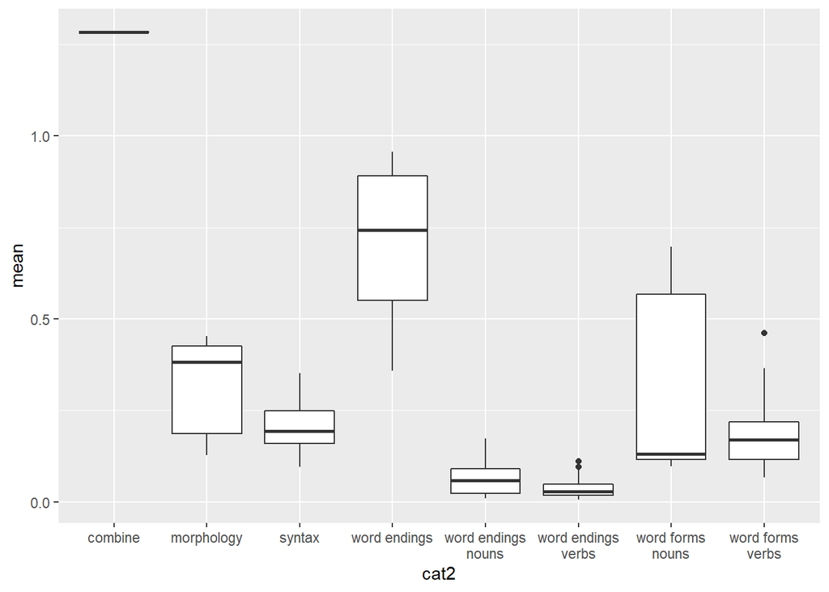

```r
Complex %>%
  filter(!is.na(out)) %>%
  group_by(definition) %>%
  summarise(
    mean=mean(out),
    category = first(complexity_category),
    cat2 = str_replace(category, "_", " " ) %>% str_replace("_", "\n" )
  ) %>%
  ggplot(aes(x=cat2, y= mean)) + geom_boxplot()
```

It seems like the word endings and the combine words variable have higher means than the morphological and syntactic complexity items (though they are ordinal, but when I treated these as binary in an older version the results were similar). The over-regularization items have very low means, and the word forms looks a bit like the syntactic and morphological complexity.

One difficulty I just thought of is that the we would expect the word form and over-regularization to be non-monotonicaly related to overall grammatical proficiency, given the inverse u shaped curve we typically see in the development of morphology.

Therefore, I’m going to first add the combine item and the word endings variables, see how that changes the results of the IRT model, and then plot the over-regularization and word form scores against this, to see if we see the non-monotonicity.

## 0.2 Data Preparation

Prepare data set for IRT modeling. I’m going to re-name each item to its category (morphology or syntax) and its item number so as to make some graphs easier to read.

```r
Complex_short_with_ids <- Complex %>%
  dplyr::select(data_id, value, out, complexity_category, num_item_id) %>%
  mutate(
    label = str_c(complexity_category, num_item_id)
  ) %>%
  pivot_wider(id_cols=data_id, names_from = "label", values_from="out") %>%
  dplyr::select(starts_with(c("data_id", "combine", "morphology", "syntax"))) %>%
  drop_na()

nrow(Complex_short_with_ids) == N_total - N_long - N_na
```

```
## [1] TRUE
```

```r
Complex_short_grammatical <- Complex_short_with_ids %>%
  filter(combine760 > 0) %>%
  dplyr::select(starts_with(c("morphology", "syntax"))) # need to get rid of participant names for IRT models.

N_nog <- nrow(filter(Complex_short_with_ids, combine760 == 0))

nrow(Complex_short_grammatical) == N_total - N_long - N_na -N_nog
```

```
## [1] TRUE
```

## 0.3 Dimensionality Assessment

Prior to fitting the IRT model, it’s worth looking at the correlation structure of the data to get a sense of the possible dimensionality.

### 0.3.1 First for grammatical kids only

Create tetrachoric correlation matrix (for binary data). I created a vector with labels, for labeling of the correlation plot.

```r
Complex_tetra <- tetrachoric(Complex_short_grammatical)
```

```r
rho <- Complex_tetra$rho

lab = c("1", "2", "3", "4", "5", "6", "7", "8", "9", "10", "11", "12", "13", "14", "15", "16", "17", "18", "19", "20", "21", "22", "23", "24", "25", "26", "27", "28", "29", "30", "31", "32", "33", "34", "35", "36", "37") # create labels for corPlot because the defintions are long and take up a ton of space
```

Check out the correlations

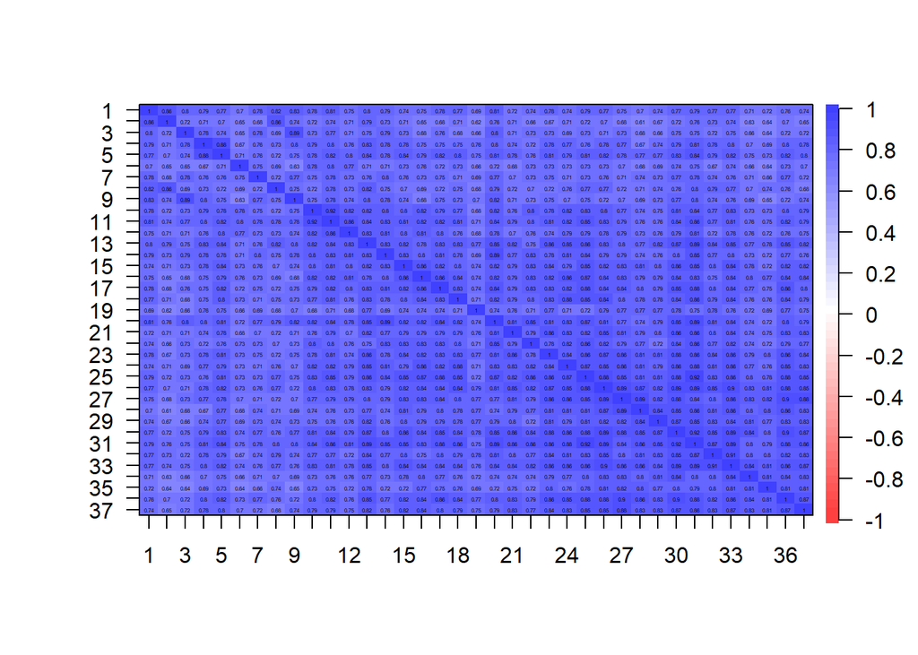

```r
corPlot(rho, labels=lab)
```

They look really high. Let’s examine the dimensionality, using princals, which is basically just a version of PCA that is appropriate for categorical data.

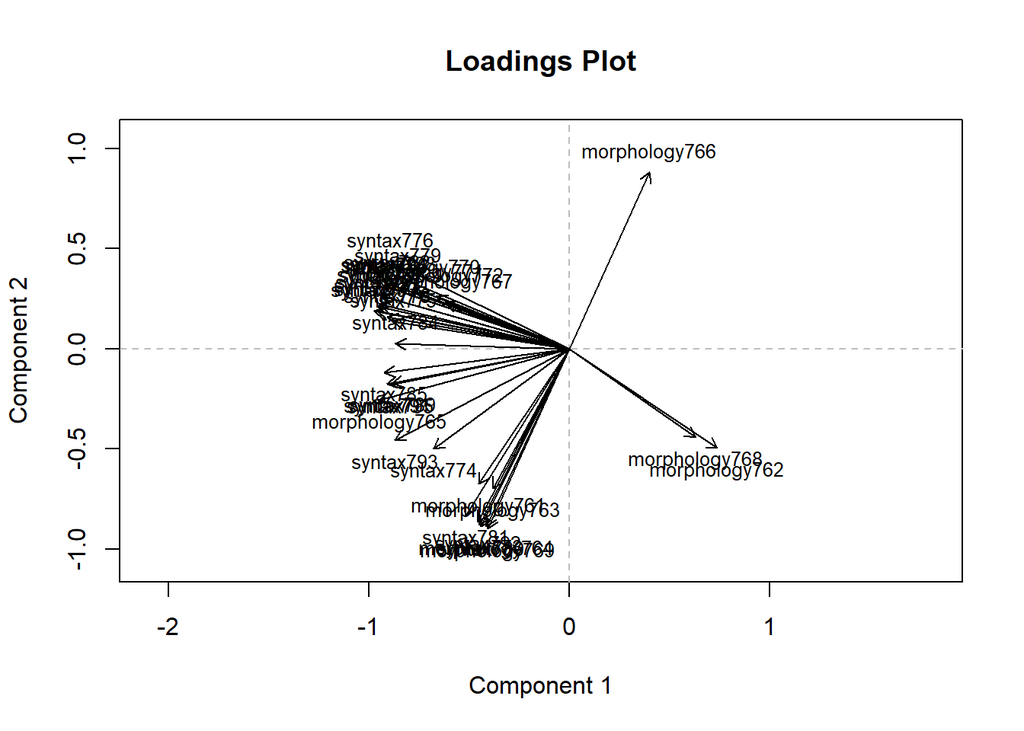

```r
pc <- princals(rho)

plot(pc)
```

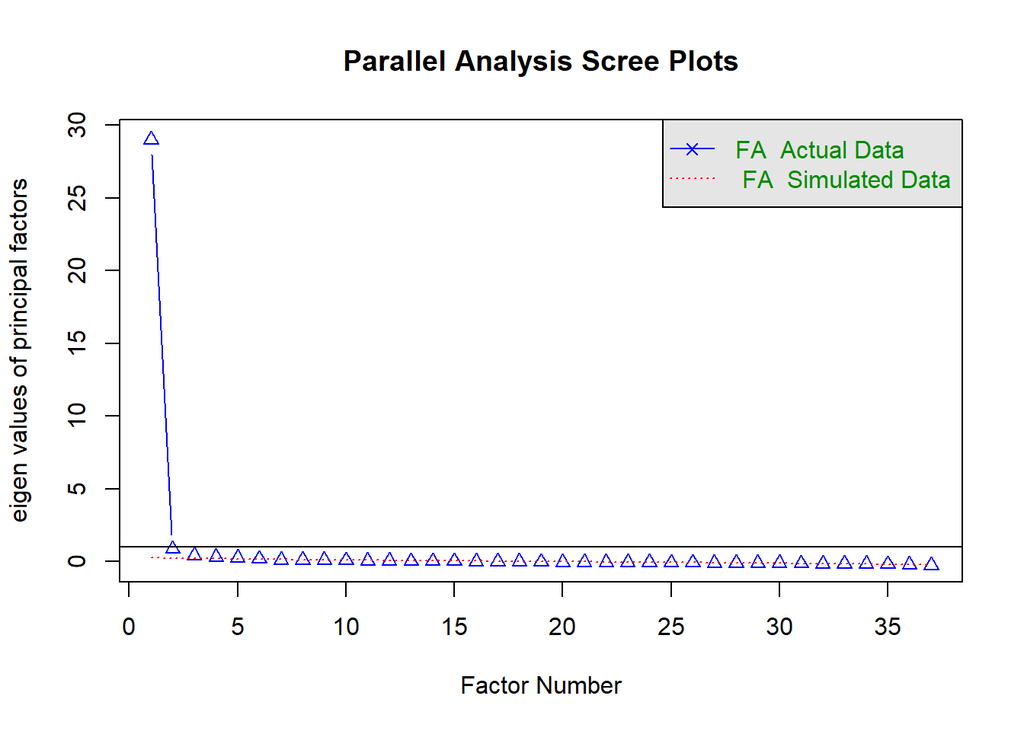

```
## Parallel analysis suggests that the number of factors =  6  and the number of components =  NA
```

```r
fa.parallel(rho, fa="fa", cor="tetra", n.obs = 2188)
```

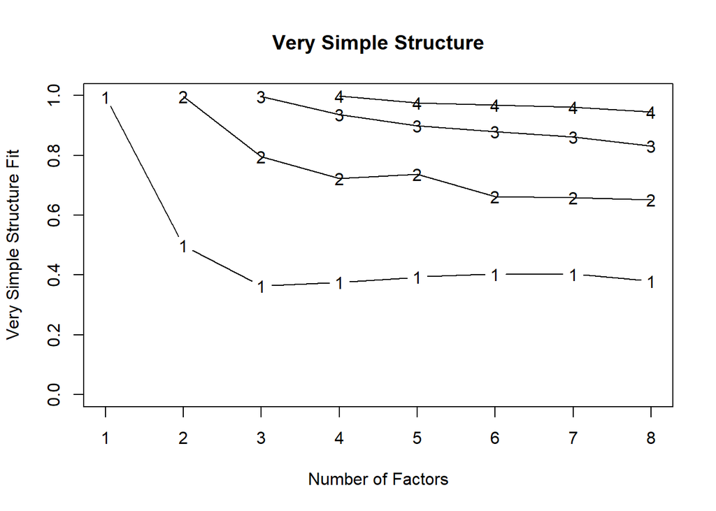

```
##
## Very Simple Structure
## Call: vss(x = rho, n.obs = 2188, cor = "tetra")
## VSS complexity 1 achieves a maximimum of 1  with  1  factors
## VSS complexity 2 achieves a maximimum of 1  with  2  factors
##
## The Velicer MAP achieves a minimum of 0.02  with  4  factors
## BIC achieves a minimum of  10778.24  with  8  factors
## Sample Size adjusted BIC achieves a minimum of  12042.74  with  8  factors
##
## Statistics by number of factors
##   vss1 vss2   map dof chisq prob sqresid fit RMSEA   BIC SABIC complex eChisq
## 1 1.00 0.00 0.024 629 28870    0     3.4   1  0.14 24033 26031     1.0   3226
## 2 0.50 1.00 0.017 593 23415    0     2.2   1  0.13 18854 20738     1.8   1530
## 3 0.36 0.80 0.016 558 20870    0     1.8   1  0.13 16578 18351     2.5   1074
## 4 0.38 0.72 0.016 524 18663    0     1.5   1  0.13 14633 16297     2.9    770
## 5 0.39 0.74 0.016 491 16982    0     1.3   1  0.12 13206 14766     3.1    600
## 6 0.40 0.66 0.017 459 15530    0     1.1   1  0.12 12000 13458     3.2    466
## 7 0.40 0.66 0.018 428 14561    0     1.0   1  0.12 11269 12629     3.3    392
## 8 0.38 0.65 0.020 398 13839    0     0.9   1  0.12 10778 12043     3.4    337
##    SRMR eCRMS  eBIC
## 1 0.033 0.034 -1612
## 2 0.023 0.024 -3030
## 3 0.019 0.021 -3217
## 4 0.016 0.018 -3260
## 5 0.014 0.017 -3176
## 6 0.013 0.015 -3064
## 7 0.012 0.014 -2899
## 8 0.011 0.014 -2724
```

```r
vss(rho, cor="tetra", n.obs = 2188)
```

# 1 IRT: Grammatical only

## 1.1 2pl model

```r
m1 <- mirt(Complex_short_grammatical, 1, itemtype="2PL")
```

[output not shown]

[output cut: 157 more lines]

[output not shown]

```r
summary(m1)
```

```
##                  F1    h2
## morphology761 0.888 0.789
## morphology762 0.838 0.703
## morphology763 0.844 0.712
## morphology764 0.878 0.771
## morphology765 0.909 0.826
## morphology766 0.831 0.691
## morphology767 0.852 0.725
## morphology768 0.865 0.749
## morphology769 0.868 0.754
## morphology770 0.909 0.827
## morphology771 0.930 0.866
## morphology772 0.897 0.805
## syntax773     0.936 0.876
## syntax774     0.908 0.824
## syntax775     0.926 0.857
## syntax776     0.933 0.870
## syntax777     0.932 0.869
## syntax778     0.916 0.839
## syntax779     0.854 0.729
## syntax780     0.930 0.864
## syntax781     0.901 0.813
## syntax782     0.906 0.821
## syntax783     0.936 0.876
## syntax784     0.925 0.856
## syntax785     0.955 0.912
## syntax786     0.951 0.905
## syntax787     0.944 0.892
## syntax788     0.917 0.841
## syntax789     0.910 0.827
## syntax790     0.956 0.914
## syntax791     0.964 0.930
## syntax792     0.922 0.850
## syntax793     0.950 0.903
## syntax794     0.901 0.812
## syntax795     0.876 0.768
## syntax796     0.952 0.907
## syntax797     0.933 0.870
##
## SS loadings:  30.643
## Proportion Var:  0.828
##
## Factor correlations:
##
##    F1
## F1  1
```

```r
M2(m1)
```

|  | M2 | df | p | RMSEA | RMSEA_5 | RMSEA_95 | SRMSR | TLI | CFI |
| --- | --- | --- | --- | --- | --- | --- | --- | --- | --- |
| stats | 2936.9 | 629 | 0 | 0.04095989 | 0.03946225 | 0.04245123 | 0.043487 | 0.9937248 | 0.9940734 |

```r
itemfit(m1)
```

| item | S_X2 | df.S_X2 | RMSEA.S_X2 | p.S_X2 |
| --- | --- | --- | --- | --- |
| morphology761 | 26.51563 | 25 | 0.005265041 | 0.38050695 |
| morphology762 | 39.84818 | 29 | 0.013078415 | 0.08644989 |
| morphology763 | 32.07571 | 28 | 0.008158276 | 0.27144074 |
| morphology764 | 37.40930 | 27 | 0.013277140 | 0.08767757 |
| morphology765 | 24.26655 | 31 | 0.000000000 | 0.79951828 |
| morphology766 | 34.28319 | 34 | 0.001951537 | 0.45416387 |
| morphology767 | 26.67912 | 31 | 0.000000000 | 0.68819144 |
| morphology768 | 27.33785 | 26 | 0.004850562 | 0.39178716 |
| morphology769 | 33.73682 | 29 | 0.008642112 | 0.24902468 |
| morphology770 | 33.72980 | 32 | 0.004971621 | 0.38379259 |

[output cut: 27 more lines]

```r
misfit <- itemfit(m1) %>% # Get labels of mis-fitting items.
  filter(p.S_X2 <= .10) %>%
  dplyr::select(item) %>%
  as.vector()

items_good <- dplyr::select(Complex_short_grammatical, -all_of(misfit$item)) # Well fitting items
items_bad <- dplyr::select(Complex_short_grammatical, all_of(misfit$item)) # Poorly fitting items

mod_fit <- mirt(items_good, 1, "2PL", verbose=FALSE) # Calculate factor scores using only the well fitting items.
Theta <- fscores(mod_fit)
```

```r
IG762<- itemGAM(items_bad$morphology762, Theta)
IG764<- itemGAM(items_bad$morphology764, Theta)
IG771<- itemGAM(items_bad$morphology771, Theta)
IG783<- itemGAM(items_bad$syntax783, Theta)
IG792<- itemGAM(items_bad$syntax792, Theta)
```

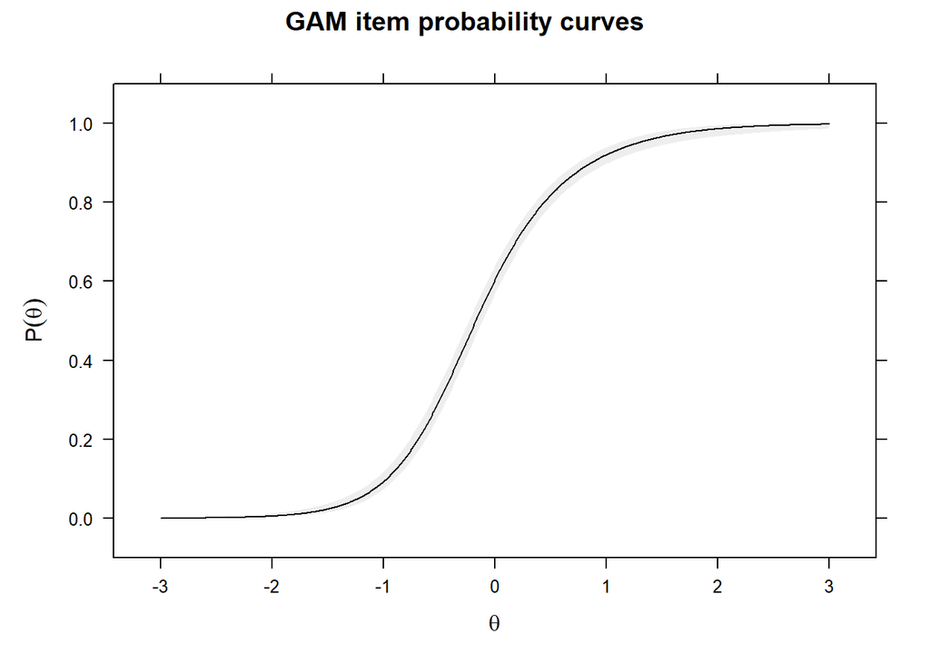

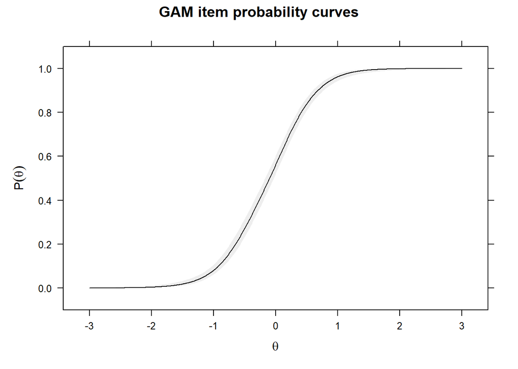

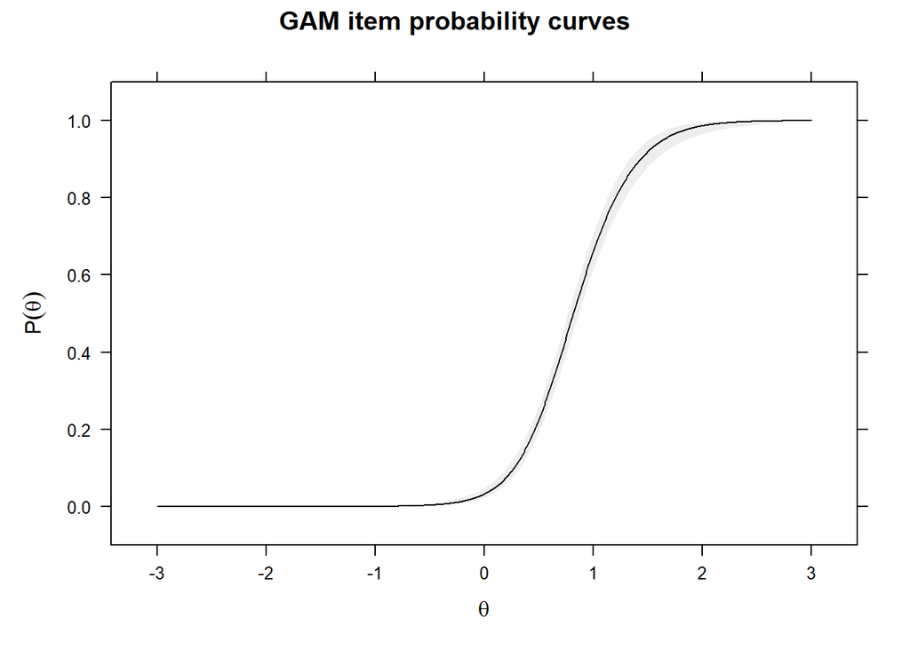

```r
plot(IG762); plot(IG764); plot(IG771)
```

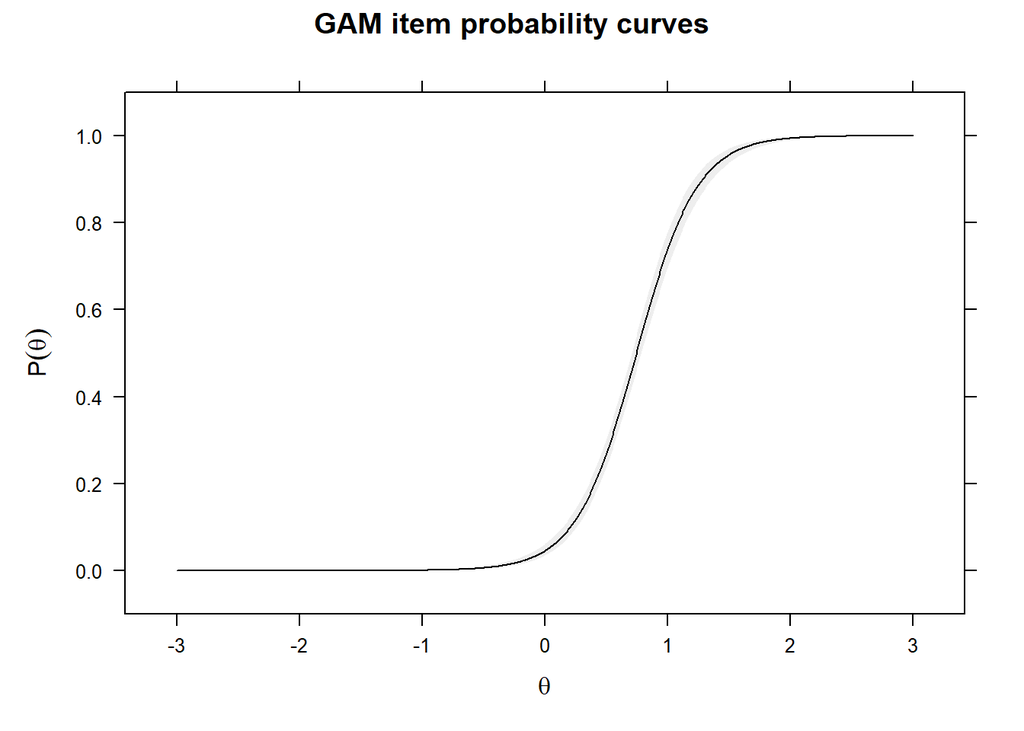

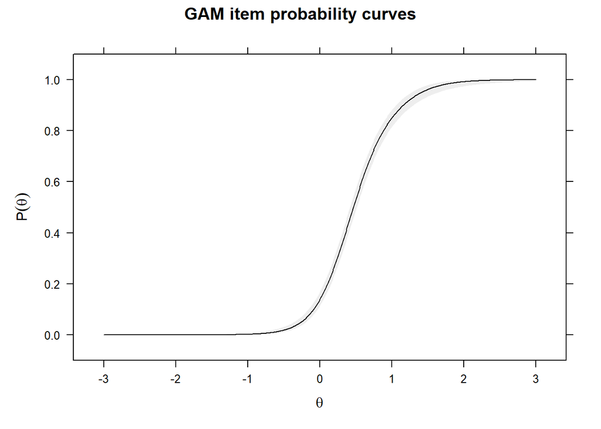

```r
plot(IG783); plot(IG792)
```

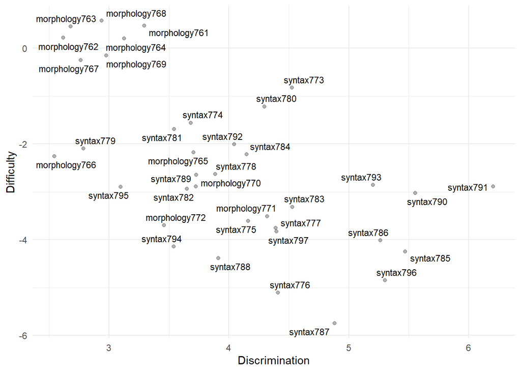

```r
coefs_2pl <- coef(m1, as.data.frame = TRUE) %>%
 t() %>%
  as_tibble() %>%
  dplyr::select(-c(149:150)) %>%
  pivot_longer(everything()) %>%
  tidyr::separate(, col=name, into=c("item", "parameter"), sep="([.])") %>%
  pivot_wider(id_cols=item, names_from=parameter, values_from=value) %>%
  dplyr::select(item, a1, d) %>%
  mutate(
   category =  gsub('[[:digit:]]+', '', item)
  )

ggplot(coefs_2pl,
       aes(x = a1, y = d)) +
  geom_point(alpha = .3) +
  ggrepel::geom_text_repel(data = coefs_2pl,
                  aes(label = item), size = 3) +
  xlab("Discrimination") +
  ylab("Difficulty") + theme_minimal()
```

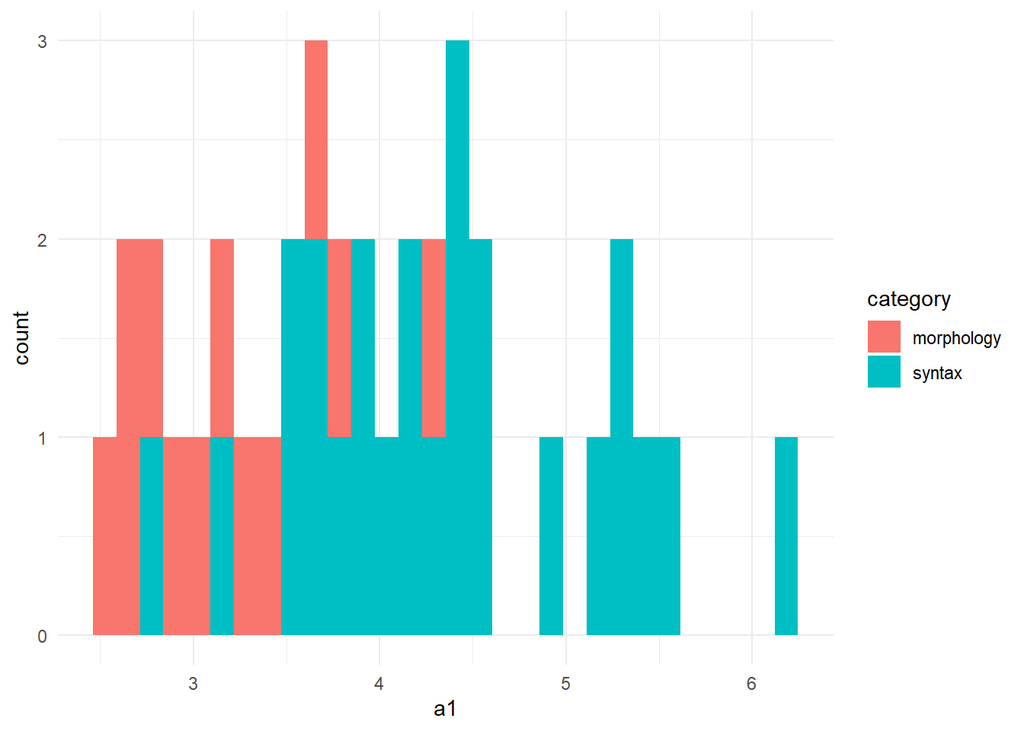

```r
ggplot(coefs_2pl, aes(x=a1, fill=category)) + geom_histogram() + theme_minimal()
```

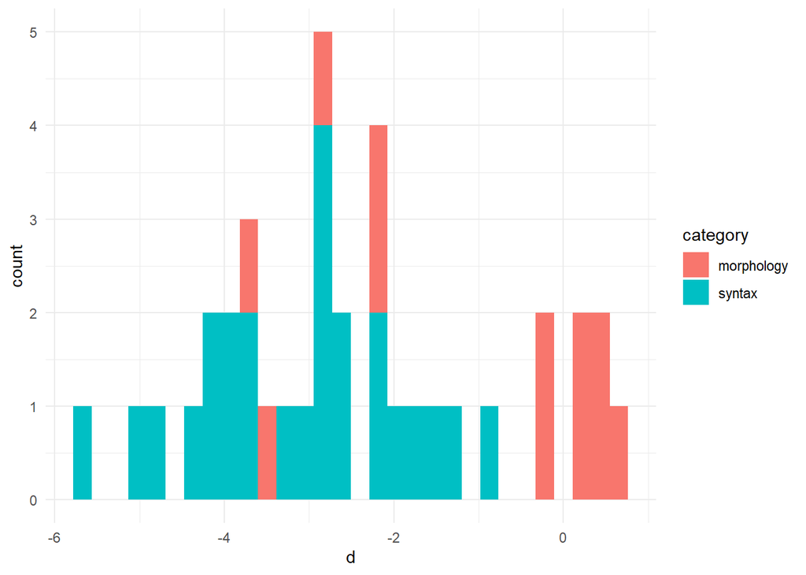

```r
ggplot(coefs_2pl, aes(x=d, fill=category)) + geom_histogram() + theme_minimal()
```

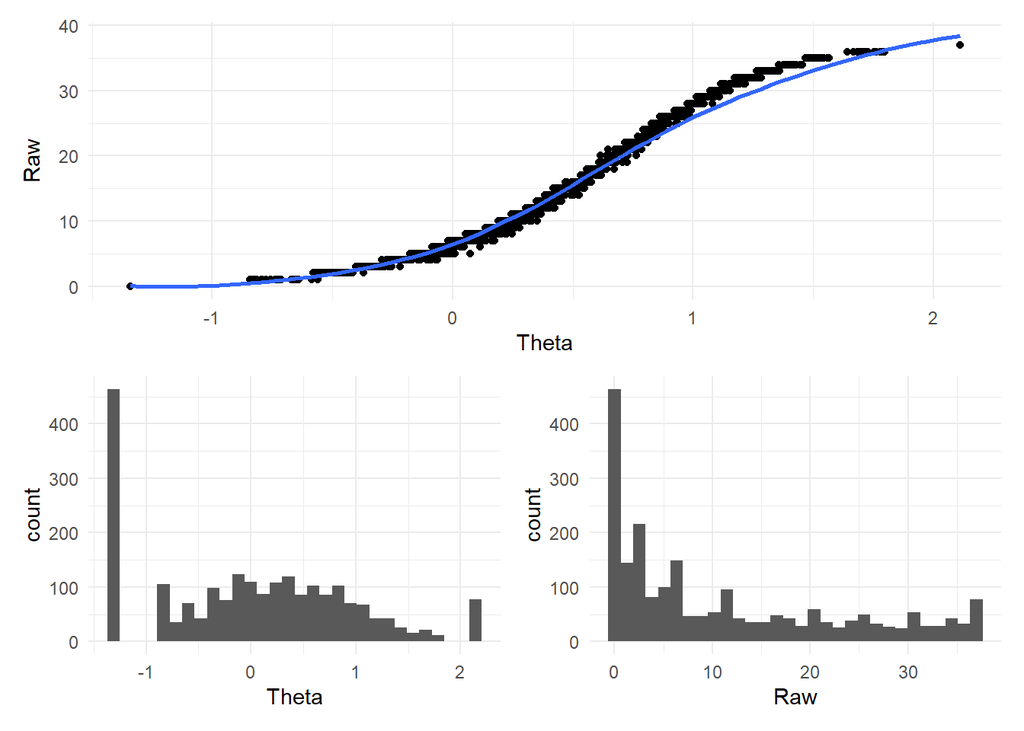

```r
true_raw <- Complex_short_grammatical %>%
  mutate(
    Raw = rowSums(.[,1:37]),
    Theta = fscores(m1)
  ) %>%
  ggplot(aes(x=Theta, y=Raw)) + geom_point() + stat_smooth(method="loess") + theme_minimal()

raw_score <- Complex_short_grammatical %>%
  mutate(
    Raw = rowSums(.[,1:37])
    ) %>%
   ggplot(aes(x=Raw)) + geom_histogram() + theme_minimal()

true_score <- Complex_short_grammatical %>%
  mutate(
    Theta = fscores(m1)
    ) %>%
   ggplot(aes(x=Theta)) + geom_histogram() + theme_minimal()

library(patchwork)

true_raw/(true_score + raw_score)
```

There are still some 0s but this is considerably fewer than the dataset with all participants included.

### 1.1.1 Dimensionality

Exploratory 2 dimensional IRT.

```r
m2 <- mirt(Complex_short_grammatical, 2, itemtype="2PL", verbose=FALSE)
```

```r
M2(m2)
```

|  | M2 | df | p | RMSEA | RMSEA_5 | RMSEA_95 | SRMSR | TLI | CFI |
| --- | --- | --- | --- | --- | --- | --- | --- | --- | --- |
| stats | 1763.334 | 593 | 0 | 0.03004022 | 0.02842228 | 0.03165545 | 0.0260783 | 0.9966247 | 0.9969946 |

```r
anova(m1, m2)
```

```
##
## Model 1: mirt(data = Complex_short_grammatical, model = 1, itemtype = "2PL")
## Model 2: mirt(data = Complex_short_grammatical, model = 2, itemtype = "2PL",
##     verbose = FALSE)
```

| AIC | AICc | SABIC | HQ | BIC | logLik | X2 | df | p |
| --- | --- | --- | --- | --- | --- | --- | --- | --- |
| 50046.54 | 50051.79 | 50232.54 | 50200.46 | 50467.65 | -24949.27 | NaN | NaN | NaN |
| 49256.92 | 49268.68 | 49533.42 | 49485.72 | 49882.90 | -24518.46 | 861.6163 | 36 | 0 |

```r
summary(m2, "oblimin", suppress=.20)
```

```
##
## Rotation:  oblimin
##
## Rotated factor loadings:
##
##                   F1     F2    h2
## morphology761 -0.828  0.268 0.827
## morphology762 -0.795     NA 0.718
## morphology763 -0.748  0.417 0.832
## morphology764 -0.839     NA 0.779
## morphology765 -0.889     NA 0.817
## morphology766 -0.797     NA 0.696
## morphology767 -0.800  0.222 0.746
## morphology768 -0.843     NA 0.750
## morphology769 -0.791  0.352 0.837
## morphology770 -0.875     NA 0.843
## morphology771 -0.894     NA 0.891
## morphology772 -0.859     NA 0.826
## syntax773     -0.924     NA 0.871
## syntax774     -0.866  0.201 0.845
## syntax775     -0.910     NA 0.843
## syntax776     -0.924     NA 0.858
## syntax777     -0.922     NA 0.858
## syntax778     -0.914     NA 0.829
## syntax779     -0.856     NA 0.717
## syntax780     -0.898     NA 0.873
## syntax781     -0.916     NA 0.819
## syntax782     -0.888     NA 0.810
## syntax783     -0.944     NA 0.873
## syntax784     -0.928     NA 0.849
## syntax785     -0.950     NA 0.901
## syntax786     -0.967     NA 0.912
## syntax787     -0.962     NA 0.904
## syntax788     -0.939 -0.221 0.865
## syntax789     -0.925     NA 0.834
## syntax790     -0.967     NA 0.915
## syntax791     -0.964     NA 0.925
## syntax792     -0.935     NA 0.853
## syntax793     -0.962     NA 0.905
## syntax794     -0.915     NA 0.817
## syntax795     -0.893     NA 0.778
## syntax796     -0.967     NA 0.912
## syntax797     -0.948     NA 0.877
##
## Rotated SS loadings:  29.809 0.988
##
## Factor correlations:
##
##        F1     F2
## F1  1.000 -0.158
## F2 -0.158  1.000
```

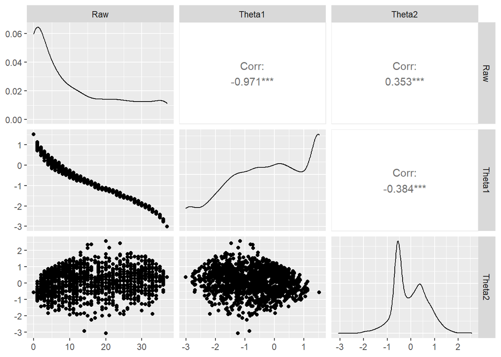

```r
Complex_short_grammatical %>%
  mutate(
    Raw = rowSums(.[,1:37]),
    Theta1 = fscores(m2)[,1],
    Theta2 = fscores(m2)[,2]
  ) %>%
  dplyr::select(Raw, Theta1, Theta2) %>%
  ggpairs()
```

Could this be due to morphological vs syntactic complexity items?

```r
model.1 <- mirt.model('
                      F1 = 1 - 12
                      F2 = 13 - 37
                      COV=F1*F2')

m3 <- mirt(Complex_short_grammatical, model.1, "2PL", verbose=FALSE)

M2(m3)
```

|  | M2 | df | p | RMSEA | RMSEA_5 | RMSEA_95 | SRMSR | TLI | CFI |
| --- | --- | --- | --- | --- | --- | --- | --- | --- | --- |
| stats | 2267.808 | 628 | 0 | 0.03455352 | 0.03302007 | 0.03608325 | 0.02474905 | 0.9955342 | 0.995789 |

```r
summary(m3)
```

```
##                  F1    F2    h2
## morphology761 0.906 0.000 0.821
## morphology762 0.847 0.000 0.717
## morphology763 0.858 0.000 0.737
## morphology764 0.881 0.000 0.776
## morphology765 0.901 0.000 0.811
## morphology766 0.832 0.000 0.692
## morphology767 0.855 0.000 0.730
## morphology768 0.864 0.000 0.746
## morphology769 0.882 0.000 0.778
## morphology770 0.921 0.000 0.848
## morphology771 0.951 0.000 0.904
## morphology772 0.908 0.000 0.824
## syntax773     0.000 0.925 0.856
## syntax774     0.000 0.887 0.787
## syntax775     0.000 0.909 0.826
## syntax776     0.000 0.919 0.845
## syntax777     0.000 0.919 0.845
## syntax778     0.000 0.901 0.812
## syntax779     0.000 0.835 0.696
## syntax780     0.000 0.915 0.838
## syntax781     0.000 0.891 0.794
## syntax782     0.000 0.890 0.792
## syntax783     0.000 0.925 0.856
## syntax784     0.000 0.913 0.833
## syntax785     0.000 0.944 0.892
## syntax786     0.000 0.942 0.887
## syntax787     0.000 0.938 0.880
## syntax788     0.000 0.908 0.824
## syntax789     0.000 0.897 0.805
## syntax790     0.000 0.951 0.904
## syntax791     0.000 0.959 0.919
## syntax792     0.000 0.912 0.832
## syntax793     0.000 0.943 0.889
## syntax794     0.000 0.889 0.790
## syntax795     0.000 0.861 0.741
## syntax796     0.000 0.943 0.890
## syntax797     0.000 0.922 0.850
##
## SS loadings:  9.383 20.883
## Proportion Var:  0.254 0.564
##
## Factor correlations:
##
##       F1    F2
## F1 1.000 0.951
## F2 0.951 1.000
```

```r
M2(m3)
```

|  | M2 | df | p | RMSEA | RMSEA_5 | RMSEA_95 | SRMSR | TLI | CFI |
| --- | --- | --- | --- | --- | --- | --- | --- | --- | --- |
| stats | 2267.808 | 628 | 0 | 0.03455352 | 0.03302007 | 0.03608325 | 0.02474905 | 0.9955342 | 0.995789 |

```r
anova(m3, m2)
```

```
##
## Model 1: mirt(data = Complex_short_grammatical, model = model.1, itemtype = "2PL",
##     verbose = FALSE)
## Model 2: mirt(data = Complex_short_grammatical, model = 2, itemtype = "2PL",
##     verbose = FALSE)
```

| AIC | AICc | SABIC | HQ | BIC | logLik | X2 | df | p |
| --- | --- | --- | --- | --- | --- | --- | --- | --- |
| 49649.24 | 49654.63 | 49837.76 | 49805.24 | 50076.04 | -24749.62 | NaN | NaN | NaN |
| 49256.92 | 49268.68 | 49533.42 | 49485.72 | 49882.90 | -24518.46 | 462.3164 | 35 | 0 |

```r
anova(m3, m1)
```

```
##
## Model 1: mirt(data = Complex_short_grammatical, model = 1, itemtype = "2PL")
## Model 2: mirt(data = Complex_short_grammatical, model = model.1, itemtype = "2PL",
##     verbose = FALSE)
```

| AIC | AICc | SABIC | HQ | BIC | logLik | X2 | df | p |
| --- | --- | --- | --- | --- | --- | --- | --- | --- |
| 50046.54 | 50051.79 | 50232.54 | 50200.46 | 50467.65 | -24949.27 | NaN | NaN | NaN |
| 49649.24 | 49654.63 | 49837.76 | 49805.24 | 50076.04 | -24749.62 | 399.3 | 1 | 0 |

### 1.1.2 Measurement Invariance

```r
Complex_with_predictors <- Admin %>%
  dplyr::select(data_id, age, ethnicity, sex, mom_ed) %>%
  mutate(
    female = ifelse(sex=="Female", yes=1, no=0),
    age_y = ifelse(age < 25, yes=1, no=0),
    college_grad = ifelse(mom_ed %in% c("College", "Some Graduate",  "Some Graduate"), yes=1, no=0)
  ) %>%
  right_join(., Complex_short_with_ids, by="data_id") %>%
  filter(combine760 > 0)


nrow(Complex_with_predictors) ==   N_total - N_long - N_na -N_nog
```

```
## [1] TRUE
```

```r
Complex_with_predictors %>%
  summarise(
    age_missing = sum(is.na(age)),
    ethnicity_missing = sum(is.na(ethnicity)), # Some ethnicity variables missing.
    sex_missing = sum(is.na(sex)),
    college_missing = sum(is.na(college_grad))
     )
```

| age_missing | ethnicity_missing | sex_missing | college_missing |
| --- | --- | --- | --- |
| 0 | 66 | 0 | 0 |

```r
table(Complex_with_predictors$age)
```

```
##
##  16  17  18  19  20  21  22  23  24  25  26  27  28  29  30
##  66  53 191 150 121  84  91 121 382 227 135 130  99 113 225
```

```r
table(Complex_with_predictors$ethnicity)
```

```
##
##    Asian    Black    Other    White Hispanic
##       47      181       72     1736       86
```

```r
table(Complex_with_predictors$sex)
```

```
##
## Female   Male  Other
##   1111   1077      0
```

```r
table(Complex_with_predictors$college_grad)
```

```
##
##    0    1
## 1370  818
```

```r
Complex_short2 <- data.frame(Complex_short_grammatical)

dif <- lordif(Complex_short2,
              Complex_with_predictors$female,
              criterion="Chisqr",
              alpha = .01)
```

[output not shown]

[output cut: 399 more lines]

[output not shown]

```r
plot(dif)
```

[output not shown]

```r
Complex_short2 <- data.frame(Complex_short_grammatical)

dif2 <- lordif(Complex_short2,
              Complex_with_predictors$college_grad,
              criterion="Chisqr",
              alpha = .01)
```

[output not shown]

[output cut: 609 more lines]

[output not shown]

```r
plot(dif2)
```

[output not shown]

## 1.2 EH Model

```r
m1_EH <- mirt(Complex_short_grammatical, 1, itemtype="2PL", dentype = "EH")
```

[output not shown]

[output cut: 364 more lines]

[output not shown]

```r
M2(m1_EH)
```

|  | M2 | df | p | RMSEA | RMSEA_5 | RMSEA_95 | SRMSR | TLI | CFI |
| --- | --- | --- | --- | --- | --- | --- | --- | --- | --- |
| stats | 2926.77 | 509 | 0 | 0.04660411 | 0.04496238 | 0.04823938 | 0.2233816 | 0.9918762 | 0.9937913 |

```r
summary(m1_EH)
```

```
##                  F1    h2
## morphology761 0.681 0.464
## morphology762 0.591 0.349
## morphology763 0.594 0.353
## morphology764 0.666 0.444
## morphology765 0.751 0.563
## morphology766 0.612 0.374
## morphology767 0.625 0.391
## morphology768 0.632 0.399
## morphology769 0.651 0.424
## morphology770 0.757 0.573
## morphology771 0.804 0.647
## morphology772 0.731 0.534
## syntax773     0.809 0.655
## syntax774     0.747 0.558
## syntax775     0.791 0.625
## syntax776     0.809 0.655
## syntax777     0.808 0.653
## syntax778     0.768 0.590
## syntax779     0.648 0.420
## syntax780     0.793 0.629
## syntax781     0.737 0.543
## syntax782     0.751 0.564
## syntax783     0.818 0.669
## syntax784     0.788 0.620
## syntax785     0.865 0.747
## syntax786     0.857 0.734
## syntax787     0.838 0.703
## syntax788     0.773 0.598
## syntax789     0.755 0.571
## syntax790     0.864 0.747
## syntax791     0.886 0.786
## syntax792     0.781 0.610
## syntax793     0.850 0.723
## syntax794     0.737 0.543
## syntax795     0.689 0.475
## syntax796     0.859 0.738
## syntax797     0.809 0.655
##
## SS loadings:  21.325
## Proportion Var:  0.576
##
## Factor correlations:
##
##    F1
## F1  1
```

```r
itemfit(m1_EH)
```

| item | S_X2 | df.S_X2 | RMSEA.S_X2 | p.S_X2 |
| --- | --- | --- | --- | --- |
| morphology761 | 25.07428 | 26 | 0.000000000 | 0.51477375 |
| morphology762 | 35.99510 | 31 | 0.008583550 | 0.24607092 |
| morphology763 | 31.25585 | 28 | 0.007291702 | 0.30583735 |
| morphology764 | 36.30696 | 28 | 0.011647099 | 0.13494661 |
| morphology765 | 25.08240 | 31 | 0.000000000 | 0.76401940 |
| morphology766 | 35.66028 | 34 | 0.004725268 | 0.39020462 |
| morphology767 | 26.78893 | 31 | 0.000000000 | 0.68273347 |
| morphology768 | 24.71637 | 27 | 0.000000000 | 0.59035370 |
| morphology769 | 30.88679 | 29 | 0.005454290 | 0.37078082 |
| morphology770 | 33.39110 | 32 | 0.004458412 | 0.39952017 |

[output cut: 27 more lines]

```r
misfit <- itemfit(m1_EH) %>% # Get labels of mis-fitting items.
  filter(p.S_X2 <= .10) %>%
  dplyr::select(item) %>%
  as.vector()

items_good <- dplyr::select(Complex_short_grammatical, -all_of(misfit$item)) # Well fitting items
items_bad <- dplyr::select(Complex_short_grammatical, all_of(misfit$item)) # Poorly fitting items

mod_fit <- mirt(items_good, 1,  itemtype="2PL", dentype = "EH", verbose=FALSE) # Calculate factor scores using only the well fitting items.
Theta <- fscores(mod_fit)
```

```r
IG771<- itemGAM(items_bad$morphology771, Theta)
IG781<- itemGAM(items_bad$syntax781, Theta)
IG783<- itemGAM(items_bad$syntax783, Theta)
IG788<- itemGAM(items_bad$syntax788, Theta)
IG792<- itemGAM(items_bad$syntax792, Theta)
```

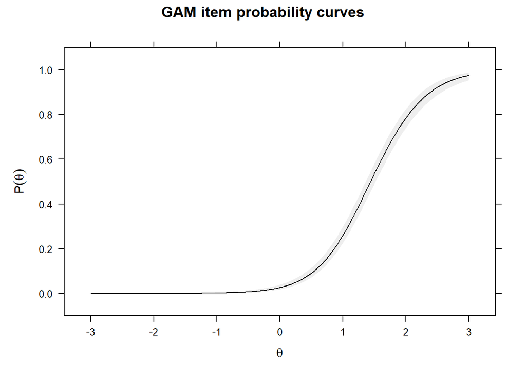

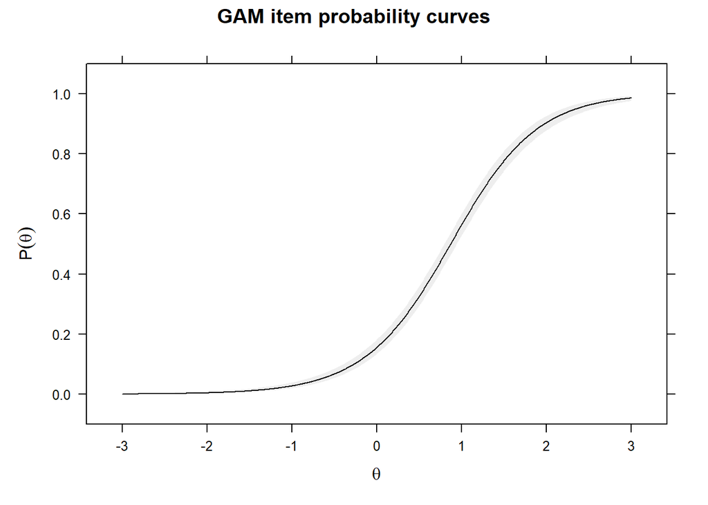

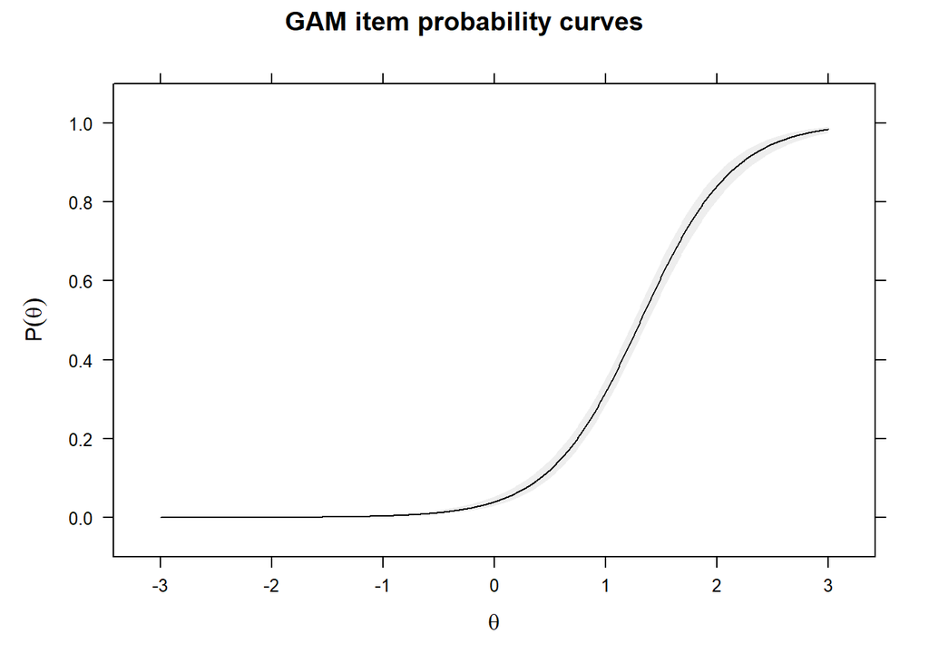

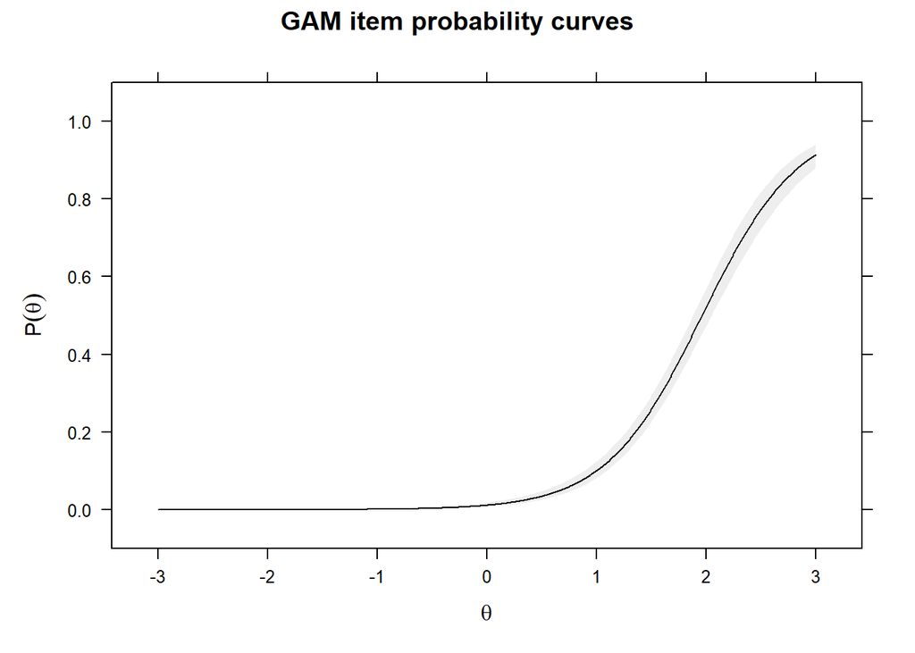

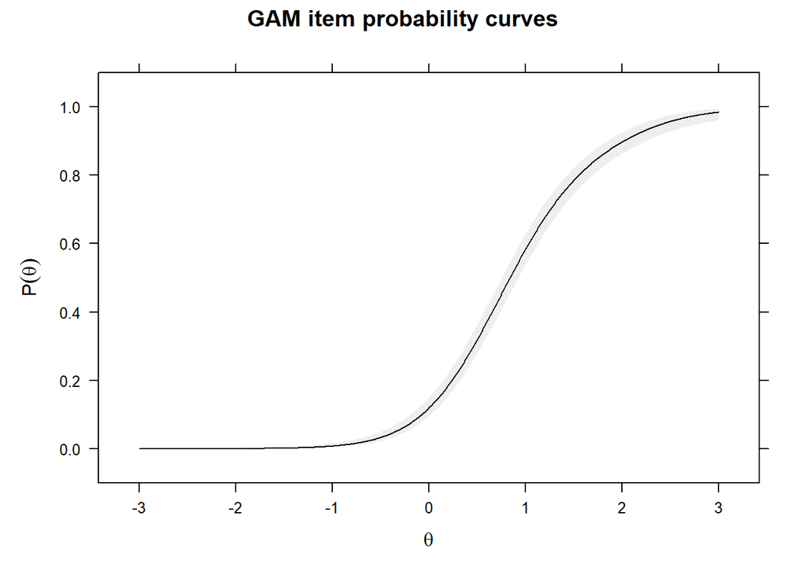

```r
plot(IG771); plot(IG781); plot(IG783); plot(IG788); plot(IG792)
```

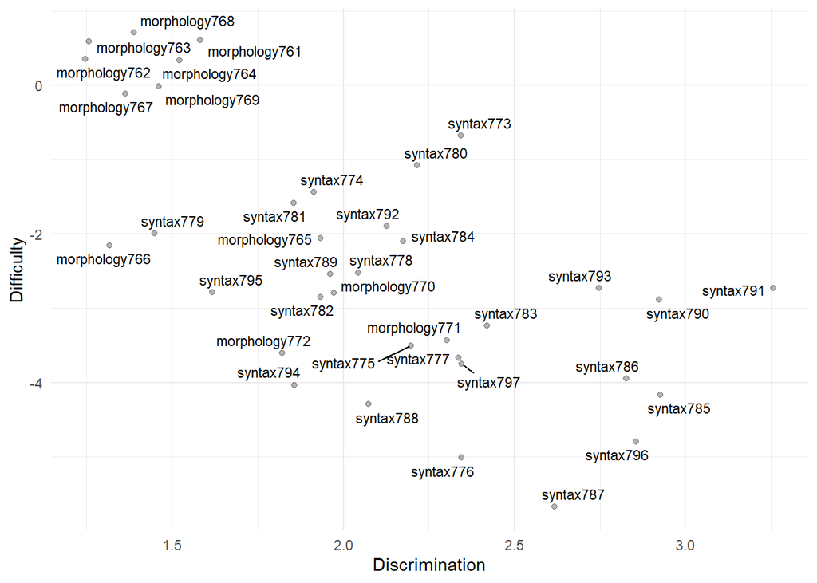

```r
coefs_EH <- coef(m1_EH, as.data.frame = TRUE) %>%
 t() %>%
  as_tibble() %>%
  dplyr::select(-c(149:150)) %>%
  pivot_longer(everything()) %>%
  tidyr::separate(, col=name, into=c("item", "parameter"), sep="([.])") %>%
  pivot_wider(id_cols=item, names_from=parameter, values_from=value) %>%
  dplyr::select(item, a1, d) %>%
  mutate(
   category =  gsub('[[:digit:]]+', '', item)
  )

ggplot(coefs_EH,
       aes(x = a1, y = d)) +
  geom_point(alpha = .3) +
  ggrepel::geom_text_repel(data = coefs_EH,
                  aes(label = item), size = 3) +
  xlab("Discrimination") +
  ylab("Difficulty") + theme_minimal()
```

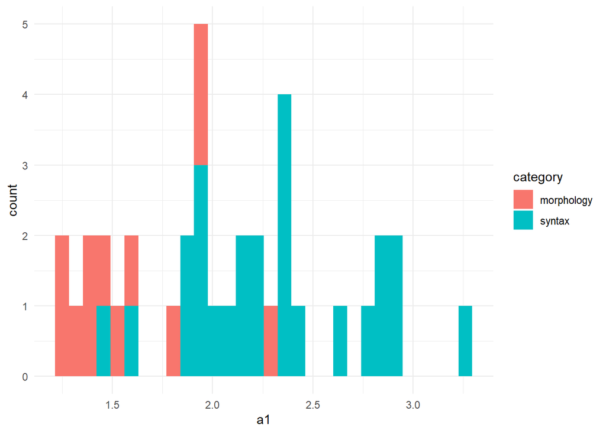

```r
ggplot(coefs_EH, aes(x=a1, fill=category)) + geom_histogram() + theme_minimal()
```

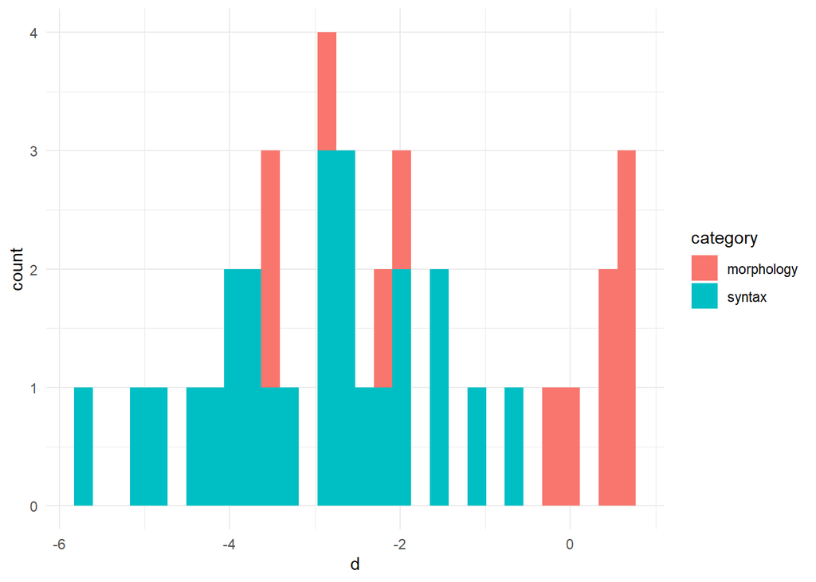

```r
ggplot(coefs_EH, aes(x=d, fill=category)) + geom_histogram() + theme_minimal()
```

### 1.2.1 Dimensionality

We can’t fit a two-dimensional model with EH latent variables, but we can test dimensionality like follows

```r
m1EH_theta <- fscores(m1_EH, use_dentype_estimate=TRUE)[,1]
complex_short_grammatical2 <- data.frame(Complex_short_grammatical)
expl.detect(complex_short_grammatical2, m1EH_theta , nclusters=2)
```

```
## Pairwise Estimation of Conditional Covariances
## ...........................................................
## Nonparametric ICC estimation
##  5% 10% 15% 20% 25% 30% 35% 40% 45% 50%
## 55% 60% 65% 70% 75% 80% 85% 90% 95%
## ...........................................................
## Nonparametric Estimation of conditional covariances
##  5% 10% 15% 20% 25% 30% 35% 40% 45% 50%
## 55% 60% 65% 70% 75% 80% 85% 90% 95%
## Pairwise Estimation of Conditional Covariances
## ...........................................................
## Nonparametric ICC estimation
##  5% 10% 15% 20% 25% 30% 35% 40% 45% 50%
## 55% 60% 65% 70% 75% 80% 85% 90% 95%
## ...........................................................
## Nonparametric Estimation of conditional covariances
##  5% 10% 15% 20% 25% 30% 35% 40% 45% 50%
## 55% 60% 65% 70% 75% 80% 85% 90% 95%
##
##
## DETECT (unweighted)
##
## Optimal Cluster Size is  2  (Maximum of DETECT Index)
##
##   N.Cluster N.items N.est N.val size.cluster DETECT.est ASSI.est RATIO.est
## 1         2      37  1094  1094        20-17       0.27    0.423     0.645
##   MADCOV100.est MCOV100.est DETECT.val ASSI.val RATIO.val MADCOV100.val
## 1         0.418      -0.005      0.245    0.432     0.583          0.42
##   MCOV100.val
## 1      -0.011
```

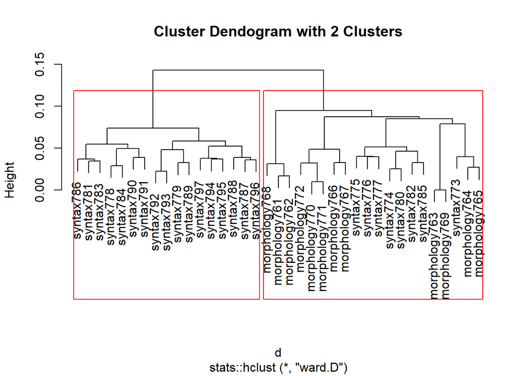

```
## $detect.unweighted
##     DETECT.val  ASSI.val RATIO.val MADCOV100.val MCOV100.val
## Cl2  0.2445946 0.4324324 0.5828151     0.4196778 -0.01113766
##
## $detect.weighted
##     DETECT.val  ASSI.val RATIO.val MADCOV100.val MCOV100.val
## Cl2  0.2445946 0.4324324 0.5828151     0.4196778 -0.01113766
##
## $clusterfit
##
## Call:
## stats::hclust(d = d, method = "ward.D")
##
## Cluster method   : ward.D
## Number of objects: 37
##
##
## $itemcluster
##             item cluster2
## 1  morphology761        1
## 2  morphology762        1
## 3  morphology763        1
## 4  morphology764        1
## 5  morphology765        1
## 6  morphology766        1
## 7  morphology767        1
## 8  morphology768        1
## 9  morphology769        1
## 10 morphology770        1
## 11 morphology771        1
## 12 morphology772        1
## 13     syntax773        1
## 14     syntax774        1
## 15     syntax775        1
## 16     syntax776        1
## 17     syntax777        1
## 18     syntax778        2
## 19     syntax779        2
## 20     syntax780        1
## 21     syntax781        2
## 22     syntax782        1
## 23     syntax783        2
## 24     syntax784        2
## 25     syntax785        1
## 26     syntax786        2
## 27     syntax787        2
## 28     syntax788        2
## 29     syntax789        2
## 30     syntax790        2
## 31     syntax791        2
## 32     syntax792        2
## 33     syntax793        2
## 34     syntax794        2
## 35     syntax795        2
## 36     syntax796        2
## 37     syntax797        2
##
## attr(,"class")
## [1] "expl.detect"
```

## 1.3 EHW Model

```r
m1_EHW <- mirt(Complex_short_grammatical, 1, itemtype="2PL", technical=list(NCYCLES=4000), dentype = "EHW")
```

[output not shown]

[output cut: 2203 more lines]

[output not shown]

```r
M2(m1_EHW)
```

|  | M2 | df | p | RMSEA | RMSEA_5 | RMSEA_95 | SRMSR | TLI | CFI |
| --- | --- | --- | --- | --- | --- | --- | --- | --- | --- |
| stats | 4296.008 | 511 | 0 | 0.05819673 | 0.05658284 | 0.05979713 | 0.1702421 | 0.987332 | 0.9902802 |

```r
summary(m1_EHW)
```

```
##                  F1    h2
## morphology761 0.943 0.889
## morphology762 0.910 0.828
## morphology763 0.911 0.830
## morphology764 0.938 0.880
## morphology765 0.960 0.922
## morphology766 0.919 0.845
## morphology767 0.924 0.854
## morphology768 0.927 0.859
## morphology769 0.933 0.870
## morphology770 0.962 0.925
## morphology771 0.971 0.944
## morphology772 0.956 0.913
## syntax773     0.972 0.945
## syntax774     0.959 0.920
## syntax775     0.969 0.938
## syntax776     0.972 0.946
## syntax777     0.972 0.945
## syntax778     0.964 0.930
## syntax779     0.932 0.869
## syntax780     0.969 0.939
## syntax781     0.957 0.916
## syntax782     0.960 0.922
## syntax783     0.974 0.949
## syntax784     0.968 0.937
## syntax785     0.982 0.964
## syntax786     0.981 0.962
## syntax787     0.978 0.956
## syntax788     0.965 0.931
## syntax789     0.961 0.924
## syntax790     0.982 0.964
## syntax791     0.985 0.971
## syntax792     0.967 0.935
## syntax793     0.980 0.960
## syntax794     0.957 0.916
## syntax795     0.945 0.892
## syntax796     0.981 0.963
## syntax797     0.972 0.946
##
## SS loadings:  33.998
## Proportion Var:  0.919
##
## Factor correlations:
##
##    F1
## F1  1
```

```r
itemfit(m1_EHW)
```

| item | S_X2 | df.S_X2 | RMSEA.S_X2 | p.S_X2 |
| --- | --- | --- | --- | --- |
| morphology761 | 24.62561 | 26 | 0.000000000 | 0.54023833 |
| morphology762 | 35.75250 | 31 | 0.008372513 | 0.25495198 |
| morphology763 | 31.74916 | 30 | 0.005163326 | 0.37928378 |
| morphology764 | 36.79234 | 28 | 0.011982536 | 0.12351128 |
| morphology765 | 26.76477 | 31 | 0.000000000 | 0.68393627 |
| morphology766 | 37.41133 | 34 | 0.006773264 | 0.31528982 |
| morphology767 | 27.09858 | 32 | 0.000000000 | 0.71312140 |
| morphology768 | 24.10816 | 28 | 0.000000000 | 0.67581372 |
| morphology769 | 30.69564 | 31 | 0.000000000 | 0.48162253 |
| morphology770 | 33.17613 | 31 | 0.005665490 | 0.36149420 |

[output cut: 27 more lines]

```r
misfit <- itemfit(m1_EHW) %>% # Get labels of mis-fitting items.
  filter(p.S_X2 <= .10) %>%
  dplyr::select(item) %>%
  as.vector()

items_good <- dplyr::select(Complex_short_grammatical, -all_of(misfit$item)) # Well fitting items
items_bad <- dplyr::select(Complex_short_grammatical, all_of(misfit$item)) # Poorly fitting items

mod_fit <- mirt(items_good, 1,  itemtype="2PL", dentype = "EHW",  technical=list(NCYCLES=4000), verbose=FALSE) # Calculate factor scores using only the well fitting items.
```

```
## EM cycles terminated after 4000 iterations.
```

```r
Theta <- fscores(mod_fit)
```

```r
IG781<- itemGAM(items_bad$syntax781, Theta)
IG783<- itemGAM(items_bad$syntax783, Theta)
IG788<- itemGAM(items_bad$syntax788, Theta)
IG792<- itemGAM(items_bad$syntax792, Theta)
```

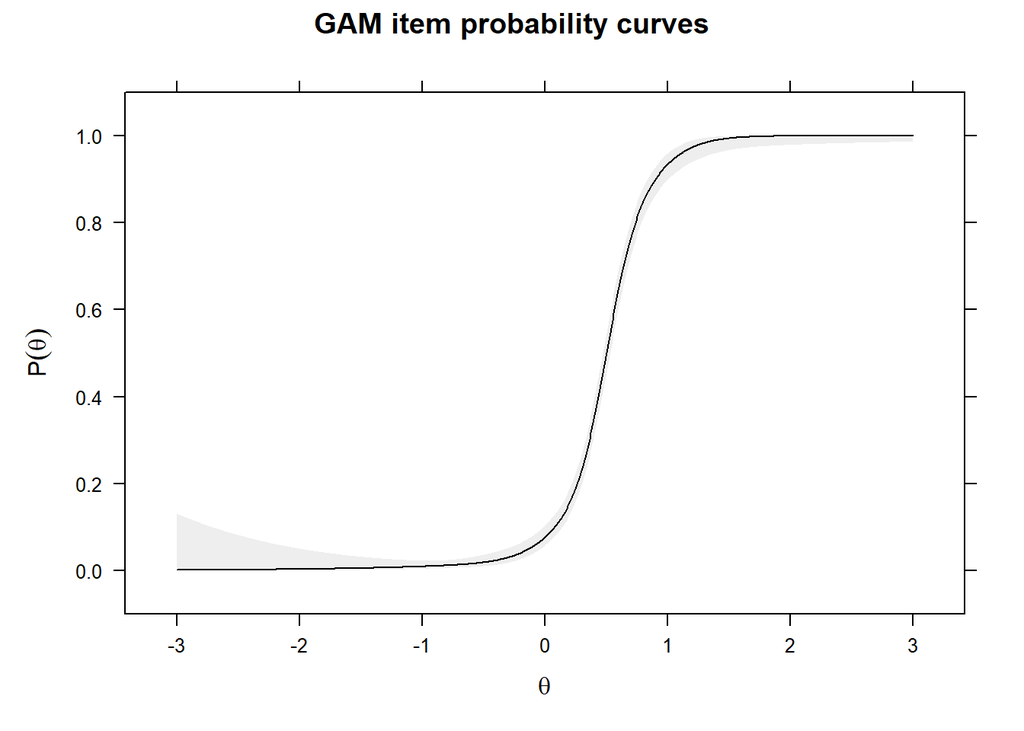

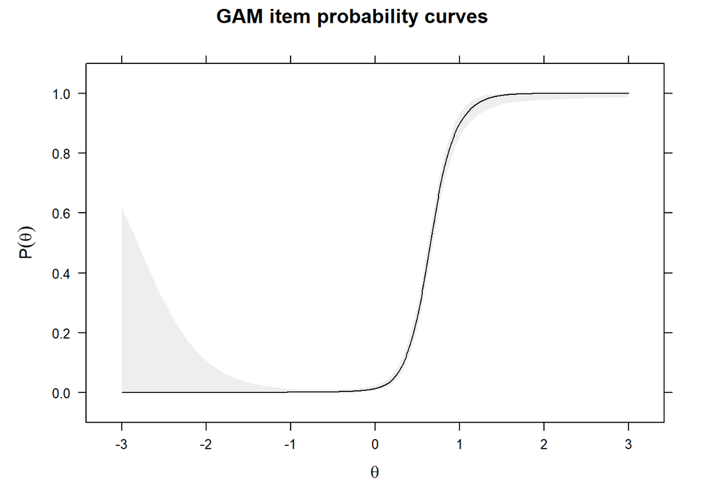

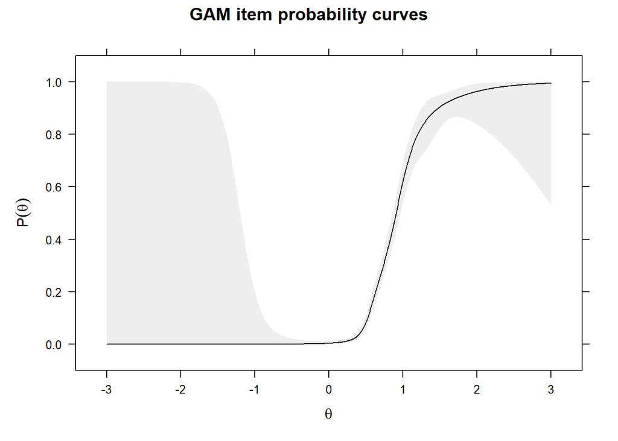

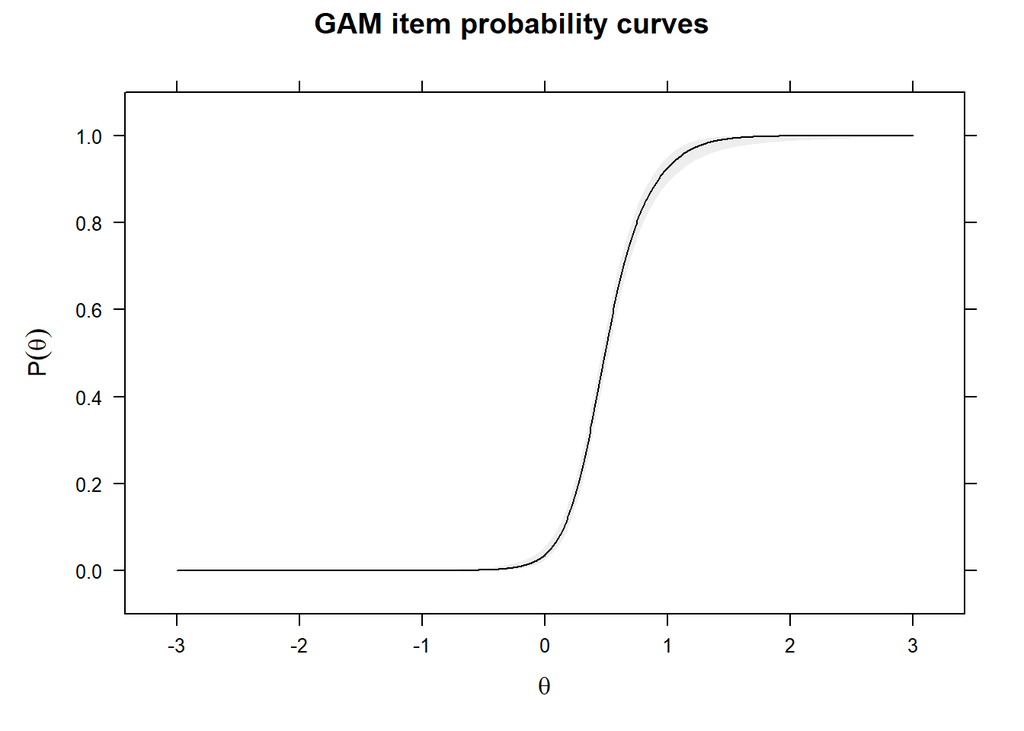

```r
plot(IG781); plot(IG783); plot(IG788); plot(IG792)
```

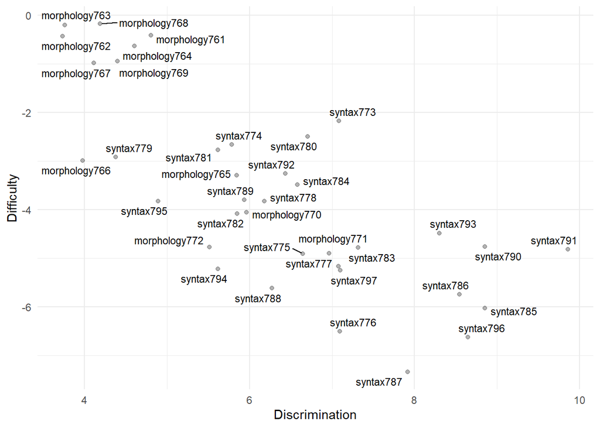

```r
coefs_EHW <- coef(m1_EHW, as.data.frame = TRUE) %>%
 t() %>%
  as_tibble() %>%
  dplyr::select(-c(149:150)) %>%
  pivot_longer(everything()) %>%
  tidyr::separate(, col=name, into=c("item", "parameter"), sep="([.])") %>%
  pivot_wider(id_cols=item, names_from=parameter, values_from=value) %>%
  dplyr::select(item, a1, d) %>%
  mutate(
   category =  gsub('[[:digit:]]+', '', item)
  )

ggplot(coefs_EHW,
       aes(x = a1, y = d)) +
  geom_point(alpha = .3) +
  ggrepel::geom_text_repel(data = coefs_EHW,
                  aes(label = item), size = 3) +
  xlab("Discrimination") +
  ylab("Difficulty") + theme_minimal()
```

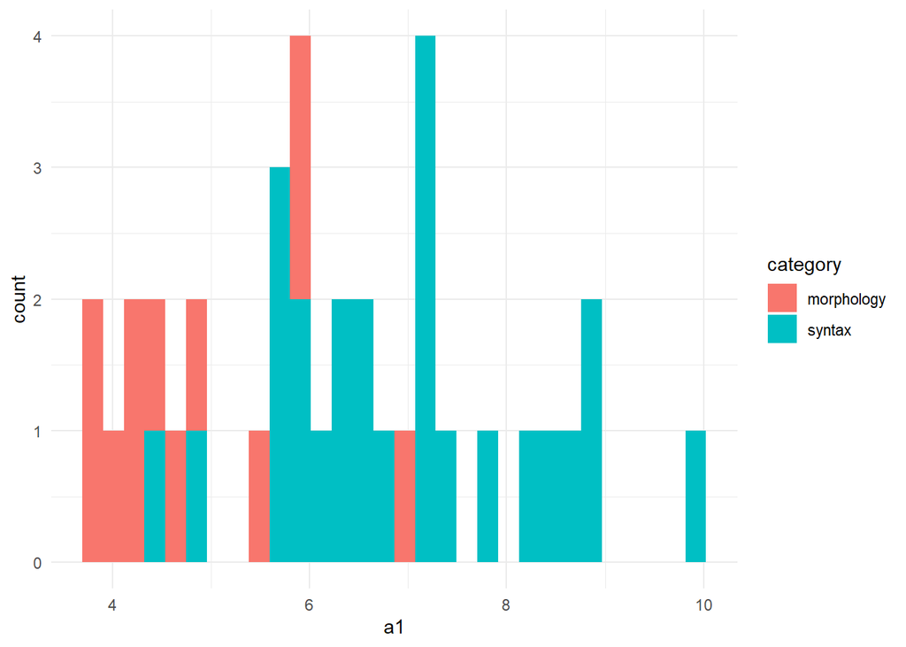

```r
ggplot(coefs_EHW, aes(x=a1, fill=category)) + geom_histogram() + theme_minimal()
```

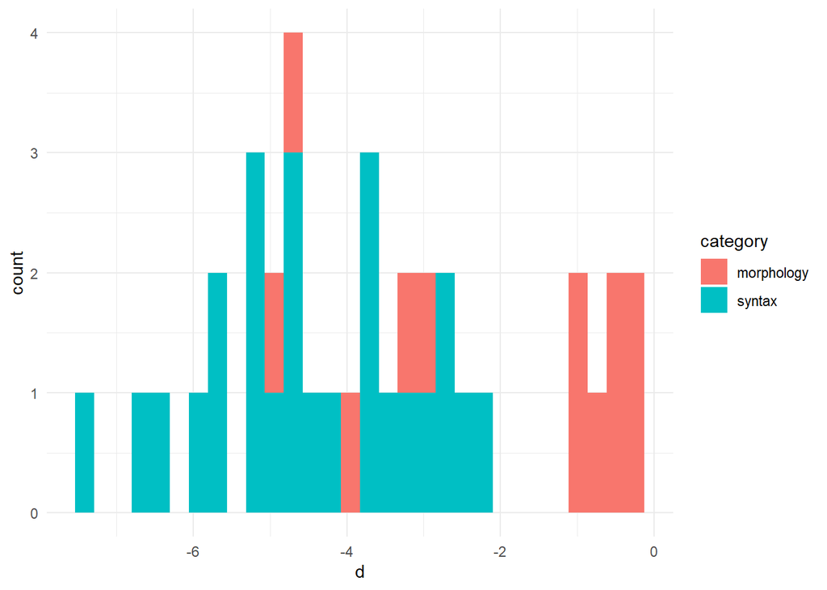

```r
ggplot(coefs_EHW, aes(x=d, fill=category)) + geom_histogram() + theme_minimal()
```

### 1.3.1 Dimensionality

```r
m1EHW_theta <- fscores(m1_EHW, use_dentype_estimate=TRUE)[,1]
expl.detect(complex_short_grammatical2, m1EHW_theta , nclusters=2)
```

```
## Pairwise Estimation of Conditional Covariances
## ...........................................................
## Nonparametric ICC estimation
##  5% 10% 15% 20% 25% 30% 35% 40% 45% 50%
## 55% 60% 65% 70% 75% 80% 85% 90% 95%
## ...........................................................
## Nonparametric Estimation of conditional covariances
##  5% 10% 15% 20% 25% 30% 35% 40% 45% 50%
## 55% 60% 65% 70% 75% 80% 85% 90% 95%
## Pairwise Estimation of Conditional Covariances
## ...........................................................
## Nonparametric ICC estimation
##  5% 10% 15% 20% 25% 30% 35% 40% 45% 50%
## 55% 60% 65% 70% 75% 80% 85% 90% 95%
## ...........................................................
## Nonparametric Estimation of conditional covariances
##  5% 10% 15% 20% 25% 30% 35% 40% 45% 50%
## 55% 60% 65% 70% 75% 80% 85% 90% 95%
##
##
## DETECT (unweighted)
##
## Optimal Cluster Size is  2  (Maximum of DETECT Index)
##
##   N.Cluster N.items N.est N.val size.cluster DETECT.est ASSI.est RATIO.est
## 1         2      37  1094  1094        23-14      0.252    0.357     0.563
##   MADCOV100.est MCOV100.est DETECT.val ASSI.val RATIO.val MADCOV100.val
## 1         0.448       0.151      0.258    0.378     0.592         0.436
##   MCOV100.val
## 1       0.116
```

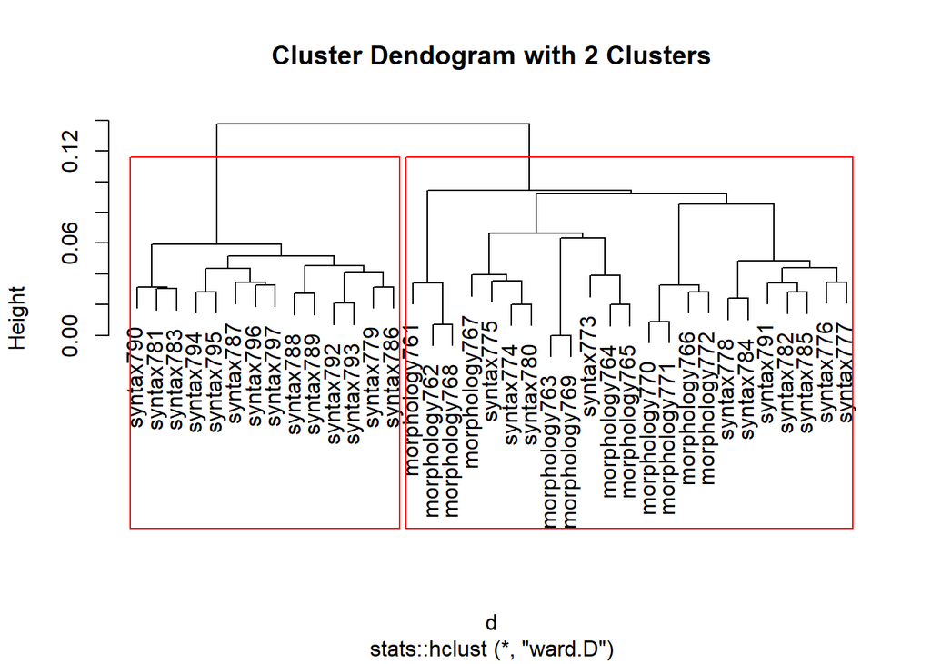

```
## $detect.unweighted
##     DETECT.val  ASSI.val RATIO.val MADCOV100.val MCOV100.val
## Cl2  0.2578406 0.3783784 0.5917915      0.435695   0.1164175
##
## $detect.weighted
##     DETECT.val  ASSI.val RATIO.val MADCOV100.val MCOV100.val
## Cl2  0.2578406 0.3783784 0.5917915      0.435695   0.1164175
##
## $clusterfit
##
## Call:
## stats::hclust(d = d, method = "ward.D")
##
## Cluster method   : ward.D
## Number of objects: 37
##
##
## $itemcluster
##             item cluster2
## 1  morphology761        1
## 2  morphology762        1
## 3  morphology763        1
## 4  morphology764        1
## 5  morphology765        1
## 6  morphology766        1
## 7  morphology767        1
## 8  morphology768        1
## 9  morphology769        1
## 10 morphology770        1
## 11 morphology771        1
## 12 morphology772        1
## 13     syntax773        1
## 14     syntax774        1
## 15     syntax775        1
## 16     syntax776        1
## 17     syntax777        1
## 18     syntax778        1
## 19     syntax779        2
## 20     syntax780        1
## 21     syntax781        2
## 22     syntax782        1
## 23     syntax783        2
## 24     syntax784        1
## 25     syntax785        1
## 26     syntax786        2
## 27     syntax787        2
## 28     syntax788        2
## 29     syntax789        2
## 30     syntax790        2
## 31     syntax791        1
## 32     syntax792        2
## 33     syntax793        2
## 34     syntax794        2
## 35     syntax795        2
## 36     syntax796        2
## 37     syntax797        2
##
## attr(,"class")
## [1] "expl.detect"
```